# Task 1: Data Understanding

## 1.1 Task Definition

1. Objective:
- This project aims to build a binary classification model using the Diabetes Prediction Dataset to predict whether an individual has diabetes.
2. Reason:
- Diabetes is a chronic condition where early detection is crucial, as it allows patients to intervene sooner, prevent complications, and reduce healthcare burdens.
- Developing an effective prediction model can significantly support doctors in their diagnostic decisions.
- Data Source: [Kaggle - Diabetes Prediction Dataset](https://www.kaggle.com/datasets/iammustafatz/diabetes-prediction-dataset)
- Dataset Overview: This dataset comprises around 100,000 health records, including features such as age, gender, smoking history, BMI, and blood sugar levels. The target variable is diabetes, where 0 indicates no diabetes and 1 indicates the presence of diabetes.

## 1.2 Data Exploration

```python
# Import necessary libraries
import pandas as pd
import numpy as np
import matplotlib.pyplot as plt
import seaborn as sns
```

```python
# Set the overall style for the plots
sns.set(style="whitegrid")
```

```python
from google.colab import drive
drive.mount('/content/drive')
```

```python
# Load the dataset
df = pd.read_csv('/content/drive/MyDrive/diabetes_prediction_dataset.csv')
```

### 1.2.1 Dataset Overview

```python
# Preview the first few rows of the data
df.head()
```

|  | gender | age | hypertension | heart_disease | smoking_history | bmi | HbA1c_level | blood_glucose_level | diabetes |
| --- | --- | --- | --- | --- | --- | --- | --- | --- | --- |
| 0 | Female | 80.0 | 0 | 1 | never | 25.19 | 6.6 | 140 | 0 |
| 1 | Female | 54.0 | 0 | 0 | No Info | 27.32 | 6.6 | 80 | 0 |
| 2 | Male | 28.0 | 0 | 0 | never | 27.32 | 5.7 | 158 | 0 |
| 3 | Female | 36.0 | 0 | 0 | current | 23.45 | 5.0 | 155 | 0 |
| 4 | Male | 76.0 | 1 | 1 | current | 20.14 | 4.8 | 155 | 0 |

```python
# View the last few rows of the dataset
df.tail()
```

|  | gender | age | hypertension | heart_disease | smoking_history | bmi | HbA1c_level | blood_glucose_level | diabetes |
| --- | --- | --- | --- | --- | --- | --- | --- | --- | --- |
| 99995 | Female | 80.0 | 0 | 0 | No Info | 27.32 | 6.2 | 90 | 0 |
| 99996 | Female | 2.0 | 0 | 0 | No Info | 17.37 | 6.5 | 100 | 0 |
| 99997 | Male | 66.0 | 0 | 0 | former | 27.83 | 5.7 | 155 | 0 |
| 99998 | Female | 24.0 | 0 | 0 | never | 35.42 | 4.0 | 100 | 0 |
| 99999 | Female | 57.0 | 0 | 0 | current | 22.43 | 6.6 | 90 | 0 |

```python
# Check the number of rows and columns in the dataset
print("Data dimensions (rows, columns):", df.shape)
```

```
Data dimensions (rows, columns): (100000, 9)
```

```python
# Inspect the data types
print("\nData types:")
print(df.info())
```

```
Data types:
<class 'pandas.core.frame.DataFrame'>
RangeIndex: 100000 entries, 0 to 99999
Data columns (total 9 columns):
 #   Column               Non-Null Count   Dtype
---  ------               --------------   -----
 0   gender               100000 non-null  object
 1   age                  100000 non-null  float64
 2   hypertension         100000 non-null  int64
 3   heart_disease        100000 non-null  int64
 4   smoking_history      100000 non-null  object
 5   bmi                  100000 non-null  float64
 6   HbA1c_level          100000 non-null  float64
 7   blood_glucose_level  100000 non-null  int64
 8   diabetes             100000 non-null  int64
dtypes: float64(3), int64(4), object(2)
memory usage: 6.9+ MB
None
```

```python
# Count missing values in each column
print("Number of missing values per column:")
print(df.isnull().sum())
```

```
Number of missing values per column:
gender                 0
age                    0
hypertension           0
heart_disease          0
smoking_history        0
bmi                    0
HbA1c_level            0
blood_glucose_level    0
diabetes               0
dtype: int64
```

```python
print(df['smoking_history'].value_counts())
```

```
smoking_history
No Info        35816
never          35095
former          9352
current         9286
not current     6447
ever            4004
Name: count, dtype: int64
```

There are no missing values in any of the columns, indicating the dataset is free from obvious gaps such as NaNs. This means the data is structurally complete, so no imputation is necessary. However, it's still important to check for hidden missing values — cases where missing information might be represented by placeholders like Unknown or similar.

```python
# Check for duplicate rows
print("Number of duplicate rows:", df.duplicated().sum())
df.drop_duplicates(inplace=True)
```

```
Number of duplicate rows: 3854
```

The dataset contains 3,854 duplicate records, meaning there are multiple identical rows. To ensure data quality, these duplicates have been removed.

```python
# Count unique values in each column
print("\nNumber of unique values per column:")
print(df.nunique())
```

```
Number of unique values per column:
gender                    3
age                     102
hypertension              2
heart_disease             2
smoking_history           6
bmi                    4247
HbA1c_level              18
blood_glucose_level      18
diabetes                  2
dtype: int64
```

This code counts the number of unique values in each column to help us understand the categories within each feature, which in turn informs how we treat the variables.

- Categorical variables like gender, hypertension, heart_disease, smoking_history, and diabetes have a limited set of values, making them suitable for classification tasks.
- Continuous variables such as age, bmi, HbA1c_level, and blood_glucose_level have many distinct values and are numerical features, which can benefit from normalization or standardization.

```
Distribution of the target variable (diabetes):
diabetes
0    0.91178
1    0.08822
Name: proportion, dtype: float64
```

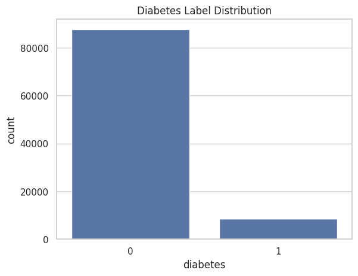

```python
# Examine the distribution of the target variable
print("Distribution of the target variable (diabetes):")
print(df['diabetes'].value_counts(normalize=True))

sns.countplot(x='diabetes', data=df)
plt.title('Diabetes Label Distribution')
plt.show()
```

Analysis of the target variable distribution:

- Class 0 (non-diabetic) accounts for approximately 91.2%
- Class 1 (diabetic) accounts for approximately 8.8%

This indicates a clear class imbalance in the dataset, with far fewer positive (diabetic) samples compared to negative ones. This imbalance needs to be addressed during model training, otherwise the model may be biased towards the majority class, increasing the risk of missed diagnoses.

### 1.2.2 Feature Analysis

```python
# Summary statistics for numerical features
numeric_cols = ['age', 'bmi', 'HbA1c_level', 'blood_glucose_level']
print(df[numeric_cols].describe())
```

```
                age           bmi   HbA1c_level  blood_glucose_level
count  96146.000000  96146.000000  96146.000000         96146.000000
mean      41.794326     27.321461      5.532609           138.218231
std       22.462948      6.767716      1.073232            40.909771
min        0.080000     10.010000      3.500000            80.000000
25%       24.000000     23.400000      4.800000           100.000000
50%       43.000000     27.320000      5.800000           140.000000
75%       59.000000     29.860000      6.200000           159.000000
max       80.000000     95.690000      9.000000           300.000000
```

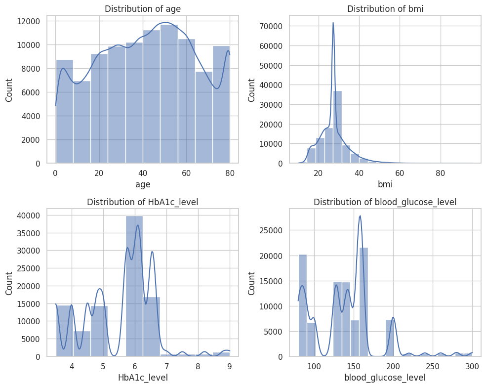

```python
# Distribution plots for numerical features

# Define number of bins for bmi and blood_glucose_level
bins_dict = {
    'bmi': 20,
    'blood_glucose_level': 20,
}

num_plots = len(numeric_cols)
cols_per_row = 2
rows = (num_plots + cols_per_row - 1) // cols_per_row

fig, axes = plt.subplots(rows, cols_per_row, figsize=(10, 8))
axes = axes.flatten()

for i, col in enumerate(numeric_cols):
    bins = bins_dict.get(col, 10)  # Default to 10 bins if not specified
    sns.histplot(data=df, x=col, bins=bins, kde=True, ax=axes[i])
    axes[i].set_title(f'Distribution of {col}')

plt.tight_layout()
plt.show()
```

From the histograms of the four numerical features, we observe the following:

- Distribution of age: The age distribution is skewed, mostly concentrated between 40 and 60 years, peaking around 50.
- Distribution of bmi: BMI shows a sharp unimodal distribution peaking near 30, with most values falling between 20 and 40 and few extreme outliers.
- Distribution of HbA1c_level: The HbA1c levels display a multimodal pattern, primarily clustering between 6 and 7.
- Distribution of blood_glucose_level: Blood glucose levels also exhibit a multimodal distribution, with peaks between 100 and 200.

```
Value counts for gender:
gender
Female    56161
Male      39967
Other        18
Name: count, dtype: int64

Value counts for hypertension:
hypertension
0    88685
1     7461
Name: count, dtype: int64

Value counts for heart_disease:
heart_disease
0    92223
1     3923
Name: count, dtype: int64

Value counts for smoking_history:
smoking_history
never          34398
No Info        32887
former          9299
current         9197
not current     6367
ever            3998
Name: count, dtype: int64
```

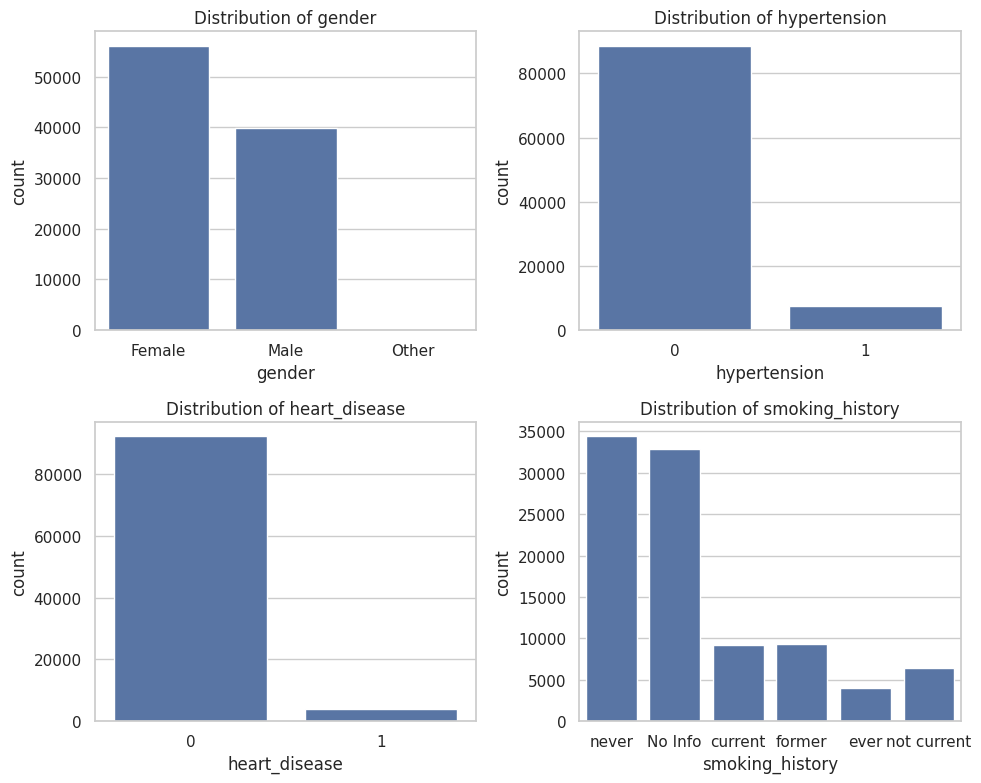

```python
# Unique value counts and visualisation of categorical features
cat_cols = ['gender', 'hypertension', 'heart_disease', 'smoking_history']

cols_per_row = 2
rows = (len(cat_cols) + cols_per_row - 1) // cols_per_row

fig, axes = plt.subplots(rows, cols_per_row, figsize=(10, 8))
axes = axes.flatten()

for i, col in enumerate(cat_cols):
    print(f"\nValue counts for {col}:")
    print(df[col].value_counts())
    sns.countplot(data=df, x=col, ax=axes[i])
    axes[i].set_title(f'Distribution of {col}')

plt.tight_layout()
plt.show()
```

From the bar charts and value counts of these four categorical features, we can observe:

- Gender: Females (56%) slightly outnumber males (40%), with a very small proportion classified as Other (0.02%).
- Hypertension: Around 7.5% of individuals have hypertension, while the majority do not.
- Heart disease: Only about 3.9% of the dataset have heart disease.
- Smoking history: The largest groups are ‘never’ smokers and those with ‘No Info’, accounting for roughly 34% and 33% respectively. Former and current smokers are roughly equal, each around 9%, while ‘not current’ and ‘ever’ smokers make up smaller proportions.

### 1.2.3 Relationships

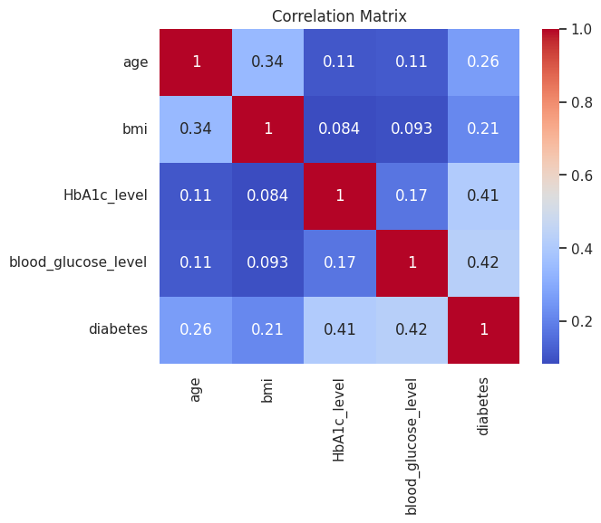

```python
# Correlation matrix of numerical features and target variable
sns.heatmap(df[numeric_cols + ['diabetes']].corr(), annot=True, cmap='coolwarm')
plt.title('Correlation Matrix')
plt.show()
```

This heatmap displays the correlation matrix, illustrating the relationships between the numerical features and the target variable (diabetes). From this, we can conclude:

- Correlation with diabetes: Both blood_glucose_level and HbA1c_level show a moderate positive correlation with diabetes, indicating they are important predictors. Age and BMI have a weaker positive correlation.
- Correlation among features: Age and BMI are moderately positively correlated, while HbA1c_level and blood_glucose_level show weak correlations with each other and with other features.

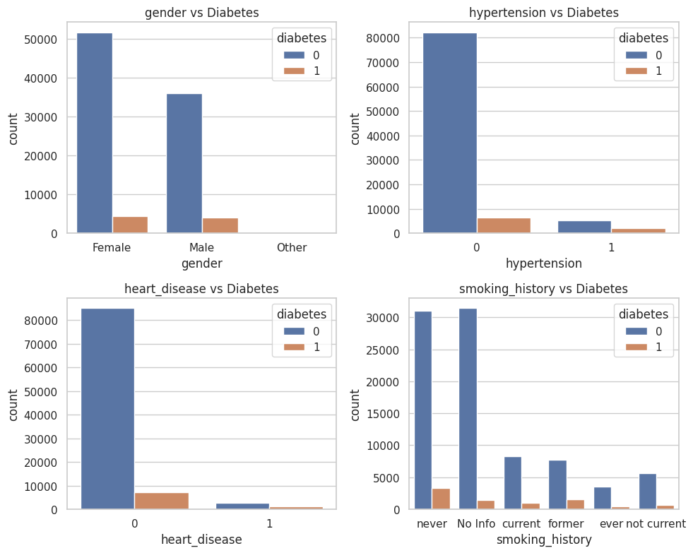

```python
# Relationship between categorical features and the target variable
fig, axes = plt.subplots(2, 2, figsize=(10, 8))
axes = axes.flatten()

for i, col in enumerate(cat_cols):
    sns.countplot(data=df, x=col, hue='diabetes', ax=axes[i])
    axes[i].set_title(f'{col} vs Diabetes')

plt.tight_layout()
plt.show()
```

From the four grouped bar charts, we can observe that:

- The prevalence of diabetes is higher among men than women.
- There is a strong positive correlation between hypertension and diabetes, suggesting that those with high blood pressure are more prone to developing diabetes.
- Similarly, heart disease shows a strong positive correlation with diabetes, indicating that patients with heart conditions may be at higher risk.
- Compared to those who never smoked, a history of smoking (whether current, former, or occasional) is associated with an increased rate of diabetes.

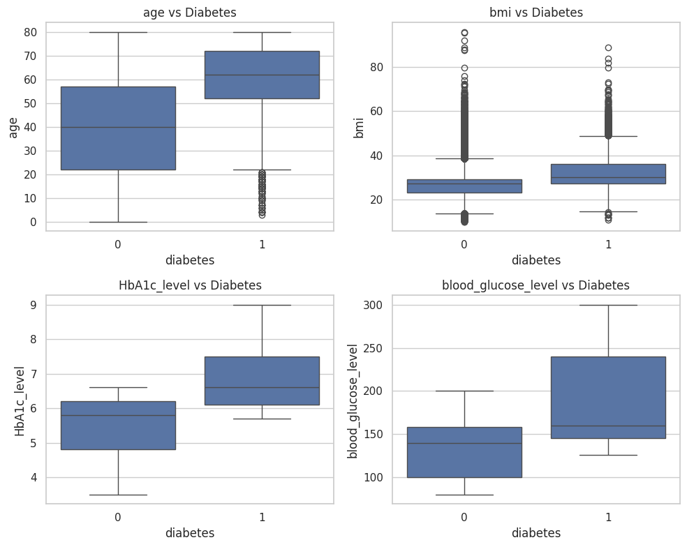

```python
# Boxplots of numerical features against the target variable
fig, axes = plt.subplots(rows, cols_per_row, figsize=(10, 8))
axes = axes.flatten()

for i, col in enumerate(numeric_cols):
    sns.boxplot(x='diabetes', y=col, data=df, ax=axes[i])
    axes[i].set_title(f'{col} vs Diabetes')

plt.tight_layout()
plt.show()
```

From the four boxplots, we can see that:

- Age is an important risk factor, with diabetic patients generally being older. The outliers in age help identify a distinct subgroup of “younger diabetic patients.”
- BMI is also related to diabetes, with diabetic individuals tending to have higher BMI, although the distinction isn’t very sharp. Outliers in BMI appear in both groups, indicating that BMI alone has a fuzzy boundary as a diagnostic indicator.
- Blood glucose level and HbA1c are the strongest distinguishing features. The distributions of these two indicators differ markedly between diabetic and non-diabetic groups, showing clear separation. No outliers were found in HbA1c or blood glucose levels for either group, suggesting their values fall within expected ranges.

### 1.2.4 Data Quality Check

```python
# Remove the very small category
# These 18 records contribute little to model training and may introduce noise or instability
df = df[df['gender'] != 'Other']
```

```python
# Check for any age values outside a reasonable range
print("Number of records with age < 0:", (df['age'] < 0).sum())
```

```
Number of records with age < 0: 0
```

```python
print(df.shape)
```

```
(96128, 9)
```

After cleaning, the dataset contains 96,128 rows and 9 columns.

### 1.2.5 Data Exploration Summary

- The dataset is suitable for a binary classification task, with the target variable being diabetes (0 indicating non-diabetic, 1 indicating diabetic).
- It contains over 100,000 records and 9 features. Overall, the data quality is good, with no missing values. A small number of duplicate rows were removed, resulting in a cleaned dataset of 96,128 records and 9 features.
- The target variable is highly imbalanced, with around 91% of samples being non-diabetic and only about 9% diabetic. This imbalance needs to be addressed in subsequent modelling steps.
- Numerical features such as HbA1c and blood glucose show a positive correlation with the target variable.
- Among categorical features, smoking history demonstrates some differentiation, particularly the “past_smoker” category which is associated with a higher risk of diabetes, indicating that smoking history is a valuable predictor.
- A very small category in gender (“Other”), comprising only 18 records, has been removed to ensure data quality.

```python
data = df.copy()
data.to_csv('cleaned_diabetes_dataset.csv', index=False)

from google.colab import files
# files.download('cleaned_diabetes_dataset.csv')
```

# Task 2: Data Preparation & Modeling

## 2.1 Data Splitting

In this project, the dataset is split into 70% training, 15% validation, and 15% testing sets.

Reasons:

- With a sufficiently large dataset, allocating 70% for training ensures the model has ample data to learn from.
- The 15% validation set is used for tuning and selecting the best model.
- The remaining 15% testing set provides an unbiased evaluation of the model’s final performance, helping to prevent data leakage.
- Since the data does not involve any time series features, a random split is appropriate and justified.

```python
from sklearn.model_selection import train_test_split

# First, split out 15% of the data as the test set
train_val_df, test_df = train_test_split(data, test_size=0.15, random_state=42, stratify=data['diabetes'])

# Then, split the remaining 85% into training and validation sets
train_df, val_df = train_test_split(train_val_df, test_size=0.1765, random_state=42, stratify=train_val_df['diabetes'])

print(f"Training set size: {train_df.shape[0]}, Validation set size: {val_df.shape[0]}, Test set size: {test_df.shape[0]}")
```

```
Training set size: 67286, Validation set size: 14422, Test set size: 14420
```

```python
# Save the datasets as CSV files
train_df.to_csv('train.csv', index=False)
val_df.to_csv('valid.csv', index=False)
test_df.to_csv('test.csv', index=False)
```

## 2.2 Preprocessing and Feature Engineering

### 2.2.1 Handling outliers and missing values

1. Outliers

During data exploration and outlier analysis in Task 1, we found some outliers in the age and bmi features.

Therefore, no outlier removal is performed on age and bmi in order to preserve potentially valuable medical information.

2. Missing values

```python
unknown_count = (df['smoking_history'] == 'No Info').sum()
print(f"Number of 'No Info': {unknown_count}")
```

```
Number of 'No Info': 32881
```

When recoding the smoking_history feature, it was found that the original data contains a substantial proportion of the “No Info” category, amounting to 32,881 records.

### 2.2.2 Feature Transformation and Encoding

- Numerical features are standardised, because models like KNN and SVM are sensitive to feature scales.
- Categorical features are encoded using one-hot encoding to avoid implying any ordinal relationship between categories.

```python
from sklearn.preprocessing import StandardScaler

numeric_cols = ['age', 'bmi', 'HbA1c_level', 'blood_glucose_level']
categorical_cols = ['gender', 'hypertension', 'heart_disease', 'smoking_history']

def recategorize_smoking(smoking_status):
    if smoking_status == 'never':
        return 'non_smoker'
    elif smoking_status == 'current':
        return 'current_smoker'
    elif smoking_status in ['ever', 'former', 'not current']:
        return 'past_smoker'
    else:
        return 'unknown'

for df_ in [train_df, val_df, test_df]:
    df_['smoking_history'] = df_['smoking_history'].apply(recategorize_smoking)
```

To retain the substantial proportion of the “No Info” category, I grouped all uncovered or missing cases into a single “unknown” category. This grouping retains the completeness of the dataset and allows the model to learn from these ‘unknown’ cases explicitly. By simplifying the smoking_history feature from multiple categories down to just four — non_smoker, current_smoker, past_smoker, and unknown — the data becomes more manageable for subsequent analysis and modelling.

```python
# Standardise the numerical features
scaler = StandardScaler()
train_df[numeric_cols] = scaler.fit_transform(train_df[numeric_cols])
val_df[numeric_cols] = scaler.transform(val_df[numeric_cols])
test_df[numeric_cols] = scaler.transform(test_df[numeric_cols])
```

By standardising the numerical features—age, BMI, HbA1c level, and blood glucose level—we ensure consistent data distribution, which facilitates more effective training of machine learning models.

```python
# One-hot encode categorical variables
train_df = pd.get_dummies(train_df, columns=categorical_cols, drop_first=True)
val_df = pd.get_dummies(val_df, columns=categorical_cols, drop_first=True)
test_df = pd.get_dummies(test_df, columns=categorical_cols, drop_first=True)

# Ensure that the validation and test sets have the same columns as the training set
val_df = val_df.reindex(columns=train_df.columns, fill_value=0)
test_df = test_df.reindex(columns=train_df.columns, fill_value=0)
```

Perform one-hot encoding on the categorical variables to convert them into numerical format suitable for machine learning models. At the same time, ensure that the training, validation, and test sets share the same feature columns to avoid errors caused by differences in categories.

### 2.2.3 Feature Selection

This dataset contains a total of nine columns, including the target variable, which means the number of features is relatively small. Considering that each feature may hold useful information, no feature selection has been performed at this stage. During model training, Random Forest and XGBoost are capable of automatically assessing feature importance, which can further enhance model performance.

## 2.3 Model Training

### 2.3.1 Algorithm Choice

Selected Models:

- Logistic Regression: Serves as a strong baseline model. It is straightforward, interpretable, and provides quick initial insights.
- Decision Tree: Capable of capturing non-linear relationships. Easy to visualise and interpret, making it suitable for understanding feature importance.
- Random Forest: An ensemble method that improves generalisation and performs well with mixed types of features. Robust to overfitting.
- LinearSVC: Compared to the standard SVM, LinearSVC uses a linear kernel, making it computationally efficient—particularly advantageous for large-scale datasets.
- K-Nearest Neighbours (KNN): A simple instance-based learning algorithm. Relies heavily on numerical features and is useful for understanding local decision boundaries.
- XGBoost: A powerful gradient boosting framework known for its high performance, regularisation capabilities, and ability to handle imbalanced datasets effectively.

This diverse model selection helps compare both simple and complex algorithms and identify the most suitable one for our dataset.

### 2.3.2 Training Process

```python
X_train = train_df.drop('diabetes', axis=1)
y_train = train_df['diabetes']

X_val = val_df.drop('diabetes', axis=1)
y_val = val_df['diabetes']
```

Separate features and labels for the training set and the validation set.

```python
from imblearn.over_sampling import SMOTE

smote = SMOTE(random_state=42)
X_train_res, y_train_res = smote.fit_resample(X_train, y_train)
```

Use SMOTE to perform oversampling in order to address potential class imbalance in the training data, thereby enhancing the model’s ability to predict the minority class.

```python
from sklearn.linear_model import LogisticRegression
from sklearn.tree import DecisionTreeClassifier
from sklearn.ensemble import RandomForestClassifier
from sklearn.svm import SVC
from sklearn.neighbors import KNeighborsClassifier
from sklearn.metrics import accuracy_score
from xgboost import XGBClassifier

from sklearn.metrics import accuracy_score

# 1. Logistic Regression
lr = LogisticRegression(C=0.1, max_iter=1000, class_weight='balanced', random_state=42)
lr.fit(X_train_res, y_train_res)

# Evaluate model performance on the original (non-resampled) training set
y_train_pred = lr.predict(X_train)
train_accuracy = accuracy_score(y_train, y_train_pred)
print("\nLogistic Regression Performance:")
print(f"Train Accuracy: {train_accuracy:.3f}")

# Perform initial validation on the validation set
y_val_pred = lr.predict(X_val)
val_accuracy = accuracy_score(y_val, y_val_pred)
print(f"Val Accuracy: {val_accuracy:.3f}")
```

```
Logistic Regression Performance:
Train Accuracy: 0.887
Val Accuracy: 0.892
```

Logistic Regression Hyperparameter Settings:

- C=0.1: A smaller value indicates stronger regularisation, which helps to prevent overfitting. It is particularly suitable for datasets with a large number of samples and a moderate number of features.
- max_iter=1000: Sets the maximum number of iterations for the solver. A higher value ensures that the optimisation process converges fully and the model has sufficient time to train properly.
- class_weight='balanced': Automatically adjusts the weights of each class to address class imbalance. This encourages the model to pay more attention to the minority class, helping to improve recall.
- random_state=42: Fixes the random seed to ensure the experiment is reproducible.

Summary:

- The accuracy score indicates that the Logistic Regression model generalizes well to unseen data, with no clear signs of overfitting or underfitting.

```python
# 2. Decision Tree
# Initialise the Decision Tree classifier with regularisation settings
dt = DecisionTreeClassifier(max_depth=4, min_samples_leaf=10, class_weight='balanced', random_state=42)
dt.fit(X_train_res, y_train_res)

# Evaluate model performance on the original training set
y_train_pred = dt.predict(X_train)
train_accuracy = accuracy_score(y_train, y_train_pred)
print("\nDecision Tree Performance:")
print(f"  Train Accuracy: {train_accuracy:.3f}")

# Evaluate model performance on the validation set
y_val_pred = dt.predict(X_val)
val_accuracy = accuracy_score(y_val, y_val_pred)
print(f"  Val Accuracy: {val_accuracy:.3f}")
```

```
Decision Tree Performance:
  Train Accuracy: 0.807
  Val Accuracy: 0.811
```

Decision Tree Hyperparameter Settings:

- max_depth=4: Limits the maximum depth of the tree to help prevent overfitting and maintain good generalisation to unseen data.
- min_samples_leaf=10: Ensures that each leaf node contains at least 10 samples, which helps avoid overly specific splits and improves model stability.
- class_weight='balanced': Automatically adjusts class weights to address class imbalance, enhancing the model’s ability to detect the minority class.
- random_state=42: Sets a fixed random seed to ensure the results are reproducible.

Summary:

- Based on the accuracy scores, we can preliminarily conclude that the Decision Tree model demonstrates good generalisation without obvious signs of overfitting or underfitting.

```python
# 3. Random Forest
rf = RandomForestClassifier(n_estimators=50, max_depth=5, class_weight='balanced', random_state=42, n_jobs=-1)
rf.fit(X_train_res, y_train_res)

# Predict on the original training set to evaluate training accuracy
y_train_pred = rf.predict(X_train)

# Predict on the validation set to evaluate validation accuracy
y_val_pred = rf.predict(X_val)

# Print the training and validation accuracy scores
print("\nRandom Forest Performance:")
print(f"  Train Accuracy: {accuracy_score(y_train, y_train_pred):.3f}")
print(f"  Val Accuracy: {accuracy_score(y_val, y_val_pred):.3f}")
```

```
Random Forest Performance:
  Train Accuracy: 0.916
  Val Accuracy: 0.918
```

Random Forest hyperparameter settings:

- n_estimators=50: Sets the number of trees in the forest, balancing training time and performance. Fifty trees is a solid starting point.
- max_depth=5: Limits the depth of each tree to control complexity and prevent overfitting.
- class_weight='balanced': Addresses class imbalance by assigning higher weights to minority classes, helping the model better identify underrepresented groups.
- random_state=42: Fixes the random seed to ensure reproducibility of results.
- n_jobs=-1: Enables parallel processing using all available CPU cores, significantly speeding up training time.

Summary:

```python
# LinearSVC
from sklearn.svm import LinearSVC

svm_linear = LinearSVC(class_weight='balanced', max_iter=10000, random_state=42)
svm_linear.fit(X_train_res, y_train_res)

# Predict on training data and validation data
y_train_pred = svm_linear.predict(X_train)
y_val_pred = svm_linear.predict(X_val)

# Print training and validation accuracy scores
print("\nLinearSVC Performance:")
print(f"  Train Accuracy: {accuracy_score(y_train, y_train_pred):.3f}")
print(f"  Val Accuracy: {accuracy_score(y_val, y_val_pred):.3f}")
```

```
LinearSVC Performance:
  Train Accuracy: 0.887
  Val Accuracy: 0.893
```

LinearSVC Hyperparameter Settings:

- class_weight='balanced': Balances the class weights to improve recognition of the minority class.
- max_iter=10000: Increases the maximum number of iterations to ensure the model converges.
- random_state=42: Sets a fixed random seed to guarantee reproducible results.

Summary:

- Based on the accuracy scores, the LinearSVC model appears to have strong generalisation ability, showing no signs of underfitting.

```python
# 5. K-Nearest Neighbors (KNN)
knn = KNeighborsClassifier(n_neighbors=10)
knn.fit(X_train_res, y_train_res)

# Predict on training data and validation data
y_train_pred = knn.predict(X_train)
y_val_pred = knn.predict(X_val)

# Print accuracy scores for training and validation sets
print("\nKNN Performance:")
print(f"  Train Accuracy: {accuracy_score(y_train, y_train_pred):.3f}")
print(f"  Val Accuracy: {accuracy_score(y_val, y_val_pred):.3f}")
```

```
KNN Performance:
  Train Accuracy: 0.932
  Val Accuracy: 0.908
```

KNeighbors hyperparameter settings:

- `n_neighbors=10`: Sets the number of neighbours to 10, which helps the model to be less sensitive to individual outliers or noisy data points, resulting in a smoother decision boundary.

Summary:

- The KNN model demonstrates strong performance, but the gap between training and validation accuracy suggests a slight degree of overfitting.

```python
# 6. XGBoost
xgb = XGBClassifier(random_state=42, eval_metric='logloss')
xgb.fit(X_train_res, y_train_res)
y_train_pred = xgb.predict(X_train)
y_val_pred = xgb.predict(X_val)

# Print accuracy scores for training and validation sets
print("\nXGBoost Performance:")
print(f"  Train Accuracy: {accuracy_score(y_train, y_train_pred):.3f}")
print(f"  Val Accuracy: {accuracy_score(y_val, y_val_pred):.3f}")
```

```
XGBoost Performance:
  Train Accuracy: 0.975
  Val Accuracy: 0.967
```

XGBoost hyperparameters settings:

- random_state=42: Ensures reproducibility of results.
- eval_metric='logloss': Specifies the loss function, suitable for binary classification tasks.

Challenges:

- XGBoost is powerful and efficient when handling tabular data, but it may face challenges with extremely large-scale datasets and highly complex relationshipsg.
- Although the accuracy is high, metrics like F1 score, precision, and recall might not be fully optimised and warrant further examination.

Summary:

- From an accuracy standpoint, the XGBoost model performs exceptionally well. This indicates that under the current tabular data and feature set, XGBoost is able to capture the vast majority of meaningful patterns. It demonstrates excellent learning and generalisation ability, achieving strong predictive performance on both the training and validation sets.

Performance Summary of Six Models:

| Model Name | Train Accuracy | Validation Accuracy |
| --- | --- | --- |
| **Logistic Regression** | 0.887 | 0.892 |
| **Decision Tree** | 0.807 | 0.811 |
| **Random Forest** | 0.916 | 0.918 |
| **LinearSVC** | 0.887 | 0.893 |
| **K-Nearest Neighbors** | 0.932 | 0.908 |
| **XGBoost** | 0.975 | 0.967 |

Based on these accuracy scores, XGBoost is clearly the best-performing model so far, followed by Random Forest. However, this is only a preliminary assessment. Beyond accuracy, a deeper comparison of their F1 scores, precision, and recall—especially regarding minority class performance—is essential. A detailed evaluation will be conducted in Task 3.

# Task 3: Evaluation

## 3.1 Select Evaluation Metrics:

Task Type: Binary Classification (Diabetes Prediction)

- Primary Metric: F1-score
- Other Metrics: Precision, Recall, ROC-AUC

Reasons:

- Since the dataset is imbalanced (only about 8.8% positive diabetes cases), accuracy alone is not a reliable metric.
- The F1-score provides a balanced measure between precision and recall, making it well-suited for imbalanced classification.
- ROC-AUC is widely used in medical diagnostics to evaluate the model’s ability to distinguish between positive and negative cases.

Ideal Metric Values:

| Metric | Ideal Range | Explanation |
| --- | --- | --- |
| Precision | 0.75 – 0.90 | Controls false positives while maintaining strong positive identification ability |
| Recall | 0.75 – 1.00 | Maximizes detection of diabetic patients, minimizing missed cases (false negatives) |
| F1-score | 0.75 – 0.90 | Balances precision and recall effectively |
| ROC-AUC | ≥ 0.90 | Indicates excellent class discrimination |

Given the focus on early screening, recall is prioritized to reduce missed diagnoses. During later diagnostic stages, precision and overall accuracy become more important to reduce false alarms.

```python
from sklearn.metrics import f1_score, precision_score, recall_score, roc_auc_score

from sklearn.metrics import f1_score, precision_score, recall_score, roc_auc_score
from sklearn.preprocessing import MinMaxScaler
import numpy as np

def evaluate_model(name, model, X_train, y_train, X_val, y_val):
    # Predict labels for training and validation sets
    y_train_pred = model.predict(X_train)
    y_val_pred = model.predict(X_val)

    auc = "N/A"  # Default value if ROC-AUC cannot be calculated

    try:
        # Try to get predicted probabilities for validation set
        y_val_proba = model.predict_proba(X_val)[:, 1]
        auc = roc_auc_score(y_val, y_val_proba)
    except AttributeError:
        try:
            y_val_scores = model.decision_function(X_val)


            if len(np.unique(y_val_scores)) > 2:
                scaler = MinMaxScaler()
                y_val_proba = scaler.fit_transform(y_val_scores.reshape(-1, 1)).flatten()
                auc = roc_auc_score(y_val, y_val_proba)
        except AttributeError:
            # If neither method is available, skip ROC-AUC calculation
            pass

    # Print evaluation metrics for training and validation sets
    print(f"\n{name} Performance:")
    print(f"  Train F1: {f1_score(y_train, y_train_pred):.3f}")
    print(f"  Val F1: {f1_score(y_val, y_val_pred):.3f}")
    print(f"  Train Precision: {precision_score(y_train, y_train_pred):.3f}")
    print(f"  Val Precision: {precision_score(y_val, y_val_pred):.3f}")
    print(f"  Train Recall: {recall_score(y_train, y_train_pred):.3f}")
    print(f"  Val Recall: {recall_score(y_val, y_val_pred):.3f}")
    print(f"  Val ROC-AUC: {auc}")

# Evaluate each model on training and validation data
evaluate_model("Logistic Regression", lr, X_train, y_train, X_val, y_val)
evaluate_model("Decision Tree", dt, X_train, y_train, X_val, y_val)
evaluate_model("Random Forest", rf, X_train, y_train, X_val, y_val)
evaluate_model("Linear SVC", svm_linear, X_train, y_train, X_val, y_val)
evaluate_model("KNN", knn, X_train, y_train, X_val, y_val)
evaluate_model("XGBoost", xgb, X_train, y_train, X_val, y_val)
```

```
Logistic Regression Performance:
  Train F1: 0.578
  Val F1: 0.590
  Train Precision: 0.430
  Val Precision: 0.443
  Train Recall: 0.879
  Val Recall: 0.884
  Val ROC-AUC: 0.9644229349786725

Decision Tree Performance:
  Train F1: 0.459
  Val F1: 0.462
  Train Precision: 0.305
  Val Precision: 0.309
  Train Recall: 0.928
  Val Recall: 0.917
  Val ROC-AUC: 0.9373442118513907

Random Forest Performance:
  Train F1: 0.647
  Val F1: 0.654
  Train Precision: 0.515
  Val Precision: 0.521
  Train Recall: 0.871
  Val Recall: 0.877
  Val ROC-AUC: 0.9703393225163495

Linear SVC Performance:
  Train F1: 0.579
  Val F1: 0.593
  Train Precision: 0.431
  Val Precision: 0.446
  Train Recall: 0.880
  Val Recall: 0.885
  Val ROC-AUC: 0.9643962303591855

KNN Performance:
  Train F1: 0.717
  Val F1: 0.613
  Train Precision: 0.565
  Val Precision: 0.486
  Train Recall: 0.982
  Val Recall: 0.827
  Val ROC-AUC: 0.9404186483794388

XGBoost Performance:
  Train F1: 0.843
  Val F1: 0.792
  Train Precision: 0.953
  Val Precision: 0.895
  Train Recall: 0.755
  Val Recall: 0.710
  Val ROC-AUC: 0.9784137957856526
```

## 3.2 Training vs. Validation Evaluation

I evaluated multiple models on training and validation sets with the metrics above. The summary table is:

[output not shown]

Analysis:

## 3.3 Error Analysis

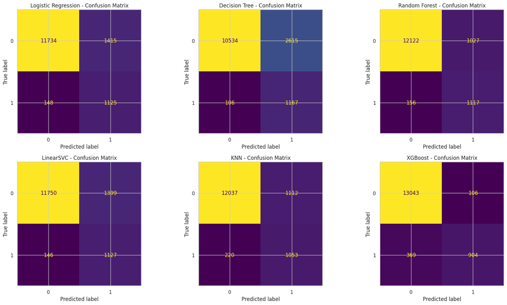

```python
# Confusion matrices for each model
models = {
    'Logistic Regression': lr,
    'Decision Tree': dt,
    'Random Forest': rf,
    'LinearSVC': svm_linear,
    'KNN': knn,
    'XGBoost': xgb
}

fig, axes = plt.subplots(2, 3, figsize=(18, 10))
axes = axes.flatten()

for ax, (name, model) in zip(axes, models.items()):
    y_val_pred = model.predict(X_val)
    cm = confusion_matrix(y_val, y_val_pred)
    disp = ConfusionMatrixDisplay(confusion_matrix=cm)
    disp.plot(ax=ax, colorbar=False)
    ax.set_title(f"{name} - Confusion Matrix")

plt.tight_layout()
plt.show()
```

Summary of Key Findings:

- Logistic Regression: High false positives (1,415), but low false negatives (148), yielding high recall (88.4%) but moderate precision (44.3%). Suitable when missing positive cases is costly.
- Decision Tree: Highest false positives (2,615) and lowest accuracy (81.1%). It minimizes missed cases but at a high cost of many false alarms.
- Random Forest: Good balance between false positives (1,027) and false negatives (156), with reasonable precision and recall (52.1% and 87.7% respectively).
- Linear SVC: Similar pattern to Logistic Regression, with moderate false positives (1,399) and high recall (88.5%).
- KNN: Misses more diabetic cases (220 false negatives), with moderate precision and recall.
- XGBoost: Best control of false positives (106) and good precision (89.5%). Recall is lower (71.0%) compared to others but balanced by very high overall accuracy (96.7%).

```python
# Analysis of False Negatives and False Positives for the XGBoost Model on the Validation Set

# Create a copy of the validation features DataFrame
X_val_df = X_val.copy()

# Retrieve the feature names from the training data
feature_names = X_train.columns.tolist()
X_val_df = pd.DataFrame(X_val, columns=feature_names)

# Add the true labels and model predictions to the DataFrame
X_val_df['True'] = y_val
X_val_df['Pred'] = xgb.predict(X_val)

# Identify false positives: cases where the true label is negative (0) but predicted as positive (1)
false_positives = X_val_df[(X_val_df['True'] == 0) & (X_val_df['Pred'] == 1)]

# Identify false negatives: cases where the true label is positive (1) but predicted as negative (0)
false_negatives = X_val_df[(X_val_df['True'] == 1) & (X_val_df['Pred'] == 0)]
```

```python
# Display some false positive samples
false_positives.head()
```

|  | age | bmi | HbA1c_level | blood_glucose_level | gender_Male | hypertension_1 | heart_disease_1 | smoking_history_non_smoker | smoking_history_past_smoker | smoking_history_unknown | True | Pred |
| --- | --- | --- | --- | --- | --- | --- | --- | --- | --- | --- | --- | --- |
| 45654 | 0.942982 | 1.931329 | 0.900862 | 0.530267 | True | True | False | False | True | False | 0 | 1 |
| 89965 | 1.209774 | 0.153114 | 0.154724 | -0.202898 | True | False | False | False | True | False | 0 | 1 |
| 38051 | 1.209774 | 0.899817 | 0.154724 | -0.202898 | False | True | False | False | True | False | 0 | 1 |
| 3057 | 0.987447 | 0.001118 | 0.154724 | -0.202898 | True | False | True | True | False | False | 0 | 1 |
| 825 | 1.209774 | 2.536365 | 0.621060 | 0.163684 | True | True | False | True | False | False | 0 | 1 |

Analysis of false positives:

- High HbA1c levels may be mistakenly interpreted as indicators of diabetes even when the individual does not actually have the disease. Older age can introduce noise, as the model might overly rely on age and HbA1c while overlooking other features. In an effort to maximise recall, the model can become somewhat "conservative"—when faced with multiple high-risk factors, it tends to predict a positive result even if current blood glucose levels are not elevated, leading to false positives. This is likely because the model interprets the combined effect of these risk factors as a strong signal for diabetes, although these individuals might actually have metabolic syndrome or other chronic conditions without meeting the criteria for a diabetes diagnosis.

```python
# Display a few false negative samples
false_negatives.head()
```

|  | age | bmi | HbA1c_level | blood_glucose_level | gender_Male | hypertension_1 | heart_disease_1 | smoking_history_non_smoker | smoking_history_past_smoker | smoking_history_unknown | True | Pred |
| --- | --- | --- | --- | --- | --- | --- | --- | --- | --- | --- | --- | --- |
| 52890 | 1.698891 | -0.813467 | 0.247991 | -0.300654 | True | False | False | False | False | False | 1 | 0 |
| 53877 | 0.142608 | -0.518328 | 0.247991 | 0.408073 | False | False | False | True | False | False | 1 | 0 |
| 85104 | 1.076378 | 0.105892 | 0.900862 | 1.507820 | False | False | False | False | True | False | 1 | 0 |
| 3315 | 1.565496 | 0.163444 | 0.900862 | -0.202898 | False | False | False | True | False | False | 1 | 0 |
| 70259 | 1.698891 | -0.137598 | 0.434526 | 0.408073 | True | False | False | True | False | False | 1 | 0 |

Summary:

These examples show that the XGBoost model struggles with individuals who fall into the grey area near the decision boundary.

Confusing cases include:

- False positives: people without diabetes but with many diabetes risk factors, who look similar to real diabetes patients.
- False negatives: people with diabetes whose key metabolic signs or related conditions are not typical or obvious, making them look like healthy individuals.

The main reason is feature overlap — some feature combinations are similar across different groups, or the model fails to detect subtle but important patterns in atypical diabetes cases.

This suggests we might need to add new features (like genetic data, lifestyle information, or other key biochemical markers) or adjust the model's penalties to better capture these subtle patterns.